# AEEM 3062

# HOMEWORK # 6

# 2022-2023 SPRING

### Name: Slade Brooks

### M#: 13801712

### DUE: 11.59 PM on 2/23/2023

## Problem 1

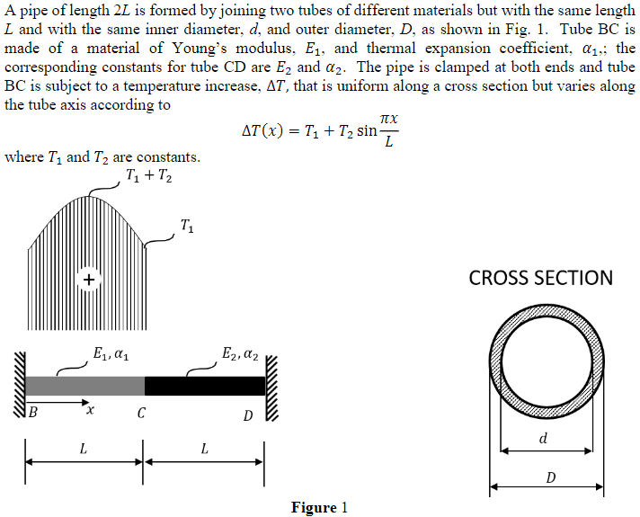

### Part A

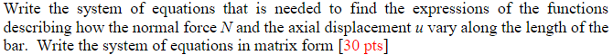

For section B-C, the body force is 0: $$ n(x) = 0 $$

Then the normal force is given by: $$ \frac{\partial N}{\partial x} + n(x) = 0 $$

$$ \frac{\partial N}{\partial x} = 0 $$

Then this is integrated to get N: $$ N(x)_{B \rightarrow C} = c_{1} $$

For a thermal expansions case, the displacement is given by: $$ \frac{du}{dx} = \frac{N(x)}{A(x)E(x)} + \alpha \Delta T $$

$$ \frac{du}{dx} = \frac{N(x)}{A(x)E(x)} + \alpha_{1} (T_{1}+T_{2}\sin{\frac{\pi x}{L}}) $$

Then this can be integrated to get: $$ u(x)_{B \rightarrow C} = \frac{c_{1}x}{A_{1}E_{1}} + \alpha_{1} T_{1}x - \frac{\alpha_{1} T_{2}L}{\pi}\cos{\frac{\pi x}{L}} + c_{2} $$

Then we can do the same for section C-D, except $\Delta T=0$, so the thermal expansion terms disappear.

The body forces are also gone in this section, so: $$ N(x)_{C \rightarrow D}=c_{3} $$

The displacement will end up the same except for expansion: $$ \frac{du}{dx} = \frac{N(x)}{A(x)E(x)} + \alpha 0 $$

$$ u(x)_{C \rightarrow D} = \frac{c_{3}x}{A_{2}E_{2}} + c_{4} $$

Then we can set the boundary conditions. For a clamped end, the displacement is 0: $$ u(0) = u(2L) = 0 $$

$$ \frac{c_{1}0}{A_{1}E_{1}} + \alpha_{1} T_{1}0 - \frac{\alpha_{1} T_{2}L}{\pi}\cos{\frac{\pi 0}{L}} + c_{2} = 0 $$

$$ c_{2} = \frac{\alpha_{1} T_{2} L}{\pi} $$

$$ \frac{c_{3}2L}{A_{2}E_{2}} + c_{4} = 0 $$

Since the pipes are connected, their displacement must be equal at the location where they meet: $$ u(L)_{B \rightarrow C} = u(L)_{C \rightarrow D} $$

$$ \frac{c_{1}L}{A_{1}E_{1}} + \alpha_{1} T_{1}L - \frac{\alpha_{1} T_{2}L}{\pi}\cos{\frac{\pi L}{L}} + c_{2} = \frac{c_{3}L}{A_{2}E_{2}} + c_{4} $$

$$ \frac{c_{1} L}{A_{1}E_{1}} + \alpha_{1}(T_{1}L + \frac{T_{2}L}{\pi}) + c_{2} = \frac{c_{3}L}{A_{2}E_{2}} + c_{4} $$

The normal forces also must be the same at that location: $$ N(L)_{B \rightarrow C} = N(L)_{C \rightarrow D} = c_{1} = c_{3} $$

Then rearrange to have all of the constants on one side: $$ \frac{c_{1}L}{A_{1}E_{1}} + c_{2} - \frac{c_{3}L}{A_{2}E_{2}} - c_{4} = -\alpha_{1}(T_{1}L + \frac{T_{2}L}{\pi}) $$

$$ c_{1} - c_{3} = 0 $$

Then the equations can be combined to create an Ax=b matrix system: $$ \fbox{$\begin{bmatrix} 0 & 1 & 0 & 0 \\ 0 & 0 & \frac{2L}{A_{2}E_{2}} & 1 \\ \frac{L}{A_{1}E_{1}} & 1 & -\frac{L}{A_{2}E_{2}} & -1 \\ 1 & 0 & -1 & 0 \end{bmatrix} \begin{bmatrix} c_{1} \\ c_{2} \\ c_{3} \\ c_{4} \end{bmatrix} = \begin{bmatrix} \frac{\alpha_{1} T_{2} L}{\pi} \\ 0 \\ -\alpha_{1}(T_{1}L + \frac{T_{2}L}{\pi}) \\ 0 \end{bmatrix}$} $$

### Part B

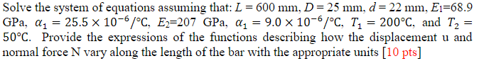

$$ \textrm{L} = 0.6 \textrm{m, }\ \textrm{D} = 0.025 \textrm{m, }\ \textrm{d} = 0.022 \textrm{m, }\ E_{1} = 6.89E10 \textrm{Pa} $$$$ \alpha_{1} = 25.5E-6 /^{\circ}C \textrm{,} \ E_{2} = 2.07E11 \textrm{Pa,} \ T_{1} = 200 ^{\circ}\textrm{C,} \ T_{2} = 50 ^{\circ}\textrm{C} $$

$$ A_{1} = A_{2} = \pi (0.025/2)^{2} - \pi (0.022/2)^{2} = 1.107E-4 m^{2} $$

We can plug the given values into the matrix and solve for the constants using Matlab: $$ \begin{bmatrix} 0 & 1 & 0 & 0 \\ 0 & 0 & 5.237E-8 & 1 \\ 7.8666E-8 & 1 & -2.6184E-8 & -1 \\ 1 & 0 & -1 & 0 \end{bmatrix} \begin{bmatrix} c_{1} \\ c_{2} \\ c_{3} \\ c_{4} \end{bmatrix} = \begin{bmatrix} 2.435E-4 \\ 0 \\ -0.0033 \\ 0 \end{bmatrix} $$

$$ c_{1} = -33795.25 \textrm{N} \quad c_{2} = 0.0002435 \textrm{m} \quad c_{3} = -33795.25 \textrm{N} \quad c_{4} = 0.00176 \textrm{m} $$

Then we can subsitute in the constants and given values to get the equations for normal force and displacement along the bar:

$$ \fbox{$N(x)_{B \rightarrow C} = -33795.25 \ \textrm{Newtons}$} $$

$$ \fbox{$N(x)_{C \rightarrow D}=-33795.25 \ \textrm{Newtons}$} $$

$$ u(x)_{B \rightarrow C} = \frac{c_{1}x}{A_{1}E_{1}} + \alpha_{1} T_{1}x - \frac{\alpha_{1} T_{2}L}{\pi}\cos{\frac{\pi x}{L}} + c_{2} $$

$$ u(x)_{B \rightarrow C} = -0.00443x + 0.0051x - (2.435E-4)\cos{5.236x} + 0.0002435 $$

$$ \fbox{$u(x)_{B \rightarrow C} = (6.7E-4)x - (2.435E-4)\cos{(5.236x)} + 0.0002435 \ \textrm{meters}$} $$

$$ u(x)_{C \rightarrow D} = \frac{c_{3}x}{A_{2}E_{2}} + c_{4} $$

$$ \fbox{$u(x)_{C \rightarrow D} = -0.001475x + 0.00176 \ \textrm{meters}$} $$

### Part C

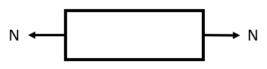

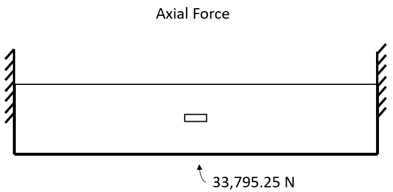

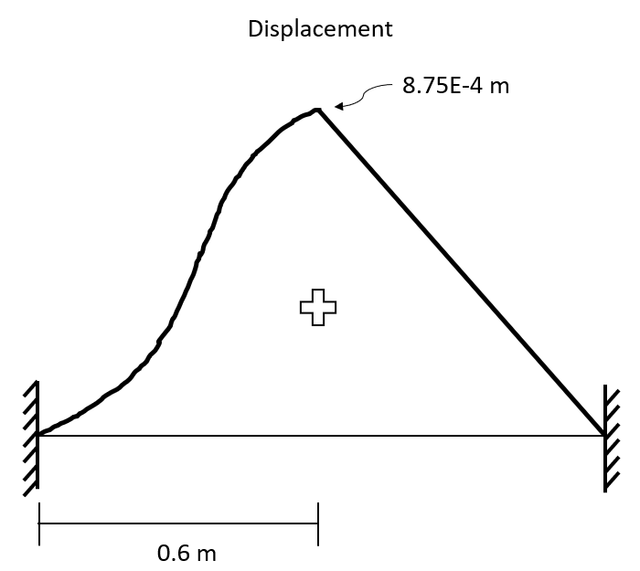

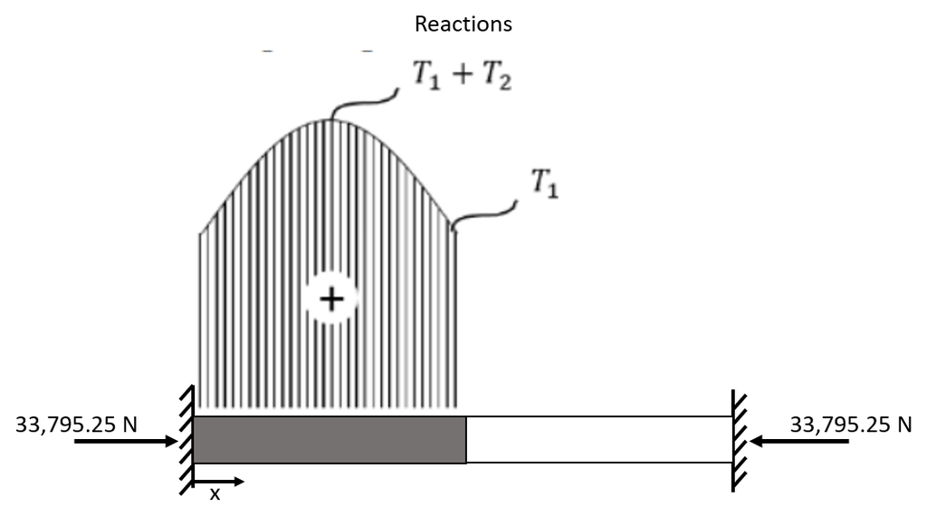

## Problem 2

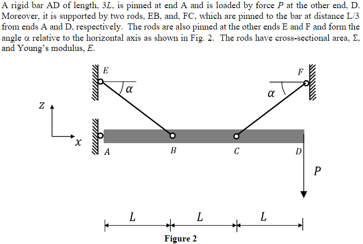

### Part A

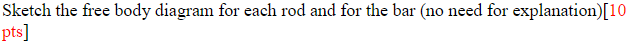

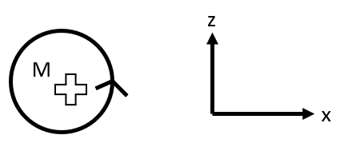

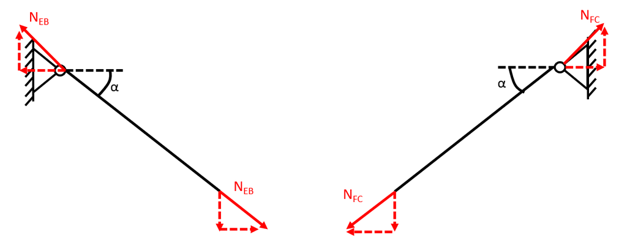

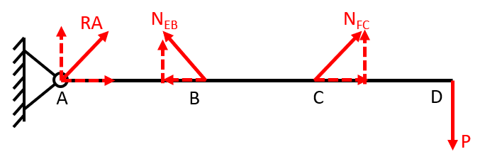

### Part B

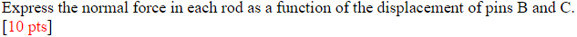

As given in the notes, the displacement of the rods can be given by: $$ \delta = \frac{Nc}{EA} $$

Both rods have length (c) given by: $$ \cos{\alpha} = \frac{L}{c}, \quad c = \frac{L}{\cos{\alpha}} $$

As well as area $\Sigma$ and young's modulus $E$ given in the problem. Therefore: $$ \delta_{B} = \frac{N_{EB}L}{E\Sigma \cos{\alpha}}, \quad \delta_{C} = \frac{N_{FC}L}{E\Sigma \cos{\alpha}} $$

Then this can be rearranged to get the normal force in terms of displacement: $$ \fbox{$N_{EB} = \frac{\delta_{B} E \Sigma \cos{\alpha}}{L}, \quad N_{FC} = \frac{\delta_{C} E \Sigma \cos{\alpha}}{L}$} $$

### Part C

Considering the angle of the bar to be $\theta$, the displacements are given by: $$ \delta_{B} = L\theta, \quad \delta_{C} = 2L \theta $$

Then we can find the ratio of displacement of B to displacement of C: $$ \frac{\delta_{B}}{\delta_{C}} = \frac{L\theta}{2L\theta} = \frac{1}{2} $$

This ratio is the same as the ratio of normal forces: $$ \frac{\delta_{B}}{\delta_{C}} = \frac{1}{2} = \frac{N_{EB}}{N_{FC}}, \quad N_{FC} = 2N_{EB} $$

We also know that the sum of the moments about pin A must be equal to 0: $$ M_{A} = 0 = -3LP + 2LN_{FCz} + LN_{EBz} $$

Then this can be solved by subsituting in $N_{FC} = 2N_{EB}$: $$ 3LP = 2L(2N_{EBz}) + LN_{EBz} \\ 5LN_{EBz} = 3LP \\ N_{EBz} = \frac{3}{5}P $$

Which means $N_{FCz}$ is: $$ N_{FCz} = 2N_{EBz} = 2(\frac{3}{5})P \\ N_{FCz} = \frac{6}{5}P $$

Then we can use trig to get $N_{EB}$ and $N_{FC}$: $$ N_{EBz} = N_{EB}\sin{\alpha}, \quad \fbox{$N_{EB} = \frac{3P}{5\sin{\alpha}}$} \\ N_{FCz} = N_{FC}\sin{\alpha}, \quad \fbox{$N_{FC} = \frac{6P}{5\sin{\alpha}}$} $$

Then to find the reactions at A we can sum the forces in the x and z directions: $$ \Sigma F_{x} = 0 = R_{Ax} - N_{EBx} + N_{FCx} = R_{Ax} - \frac{3P}{5\sin{\alpha}}\cos{\alpha} + \frac{6P}{5\sin{\alpha}}\cos{\alpha} $$

$$ \fbox{$R_{Ax} = -\frac{3}{5}P \cot{\alpha}$} $$

$$ \Sigma F_{z} = 0 = R_{Az} + N_{EBz} + N_{FCz} - P = R_{Az} + \frac{3P}{5} + \frac{6P}{5} - P $$

$$ \fbox{$R_{Az} = -\frac{4}{5}P$} $$

### Part D

The displacement of the bar at D depends on its rotation (which we previously defined as $\theta$). This gives its displacement as: $$ \delta_{D} = 3L\theta $$

Then we can solve for $\theta$ from the displacement for point B: $$ \delta_{B} = L\theta, \quad \theta = \frac{\delta_{B}}{L} $$

Then by substituting in $\delta_{B}$ and $N_{EB}$ we can solve for $\theta$: $$ \theta = \frac{\frac{N_{EB}L}{E\Sigma \cos{\alpha}}}{L} = \frac{N_{EB}}{E\Sigma \cos{\alpha}} = \frac{\frac{3P}{5\sin{\alpha}}}{E\Sigma \cos{\alpha}} = \frac{3P}{5E\Sigma \sin{\alpha}\cos{\alpha}} $$

Then substituting $\theta$ back in gives the value for $\delta_{D}$: $$ \fbox{$\delta_{D} = \frac{9PL}{5E\Sigma \sin{\alpha} \cos{\alpha}}$} $$